# Demo 9 | Local Spatial Statistics

Peter Kedron

2026-10-19

# 1. Introduction

When global statistical tests suggest that spatial autocorrelation may be present in a dataset, they leave a clear question: where within the study region is that clustering? In the prior examination of COVID-19 incidence across New England during the early pandemic, Moran’s $I$ and the General $G$ both suggested that COVID-19 incidence was spatially clustered: counties with high rates sat next to counties with high rates, and the clustering held under every spatial weights matrix we tried.

For anyone responding to the pandemic, *where* is the question that matters. A state health department deciding where to send testing sites, vaccine doses, or hospital staff needs to know which counties form the high-incidence cluster and how far it extends, which counties form a low-incidence cluster, and whether any county stands out from its surroundings, such as a high-rate county surrounded by low-rate neighbors, or the reverse. None of these questions can be answered from a global $I$ or $G$.

**Local statistics** answer these questions by calculating a separate value for every county from that county and its neighbors. Instead of one number for New England, we get 65, one per county, which can be mapped. This demonstration calculates three kinds of local results for COVID-19 incidence:

- **Local Getis–Ord $G_i$ and $G_i^*$** ask whether a county sits within a concentration of *high* incidence rates (a hot spot) or *low* incidence rates (a cold spot).
- **Local Moran’s $I_i$** asks whether a county’s rate is *similar* to its neighbors’ rates (part of a cluster) or *dissimilar* (a spatial outlier), and splits the counties into high–high, low–low, high–low, and low–high groups.
- **Permutation tests with a multiple-testing correction** ask which of these 65 results are unusual enough to report.

**Keywords:** local statistics, hot spots, Getis–Ord $G_i^*$, local Moran’s I, LISA, multiple testing

## 1.1 Data and Spatial Weights

### 1.1.1 Data

This demonstration uses the same boundary file as the global statistics demonstration. The incidence counts run to September 14, 2020.

**New England counties (`NewEngland.shp`):** 65 of the 67 counties of New England, projected to WGS 1984 UTM Zone 19N (meters). Two attributes are rates:

- `Incident_R`: the incidence rate, confirmed COVID-19 cases per 100,000 residents. This is the variable analyzed throughout the demonstration.
- `Case_FR`: the case fatality rate, deaths as a percentage of confirmed cases.

The two missing counties, Dukes and Nantucket, are the islands of Martha’s Vineyard and Nantucket. In the terms of Boots and Okabe (2007), the counties are therefore an *incomplete tessellation* of New England rather than a complete one, so counties along the coast and around the gap have fewer neighbors, and their local statistics are based on less information.

```r
# Load the New England county boundaries and their COVID-19 attributes
ne <- st_read("NewEngland.shp", quiet = TRUE) %>%
  mutate(rate = as.numeric(Incident_R),
         name = paste0(COUNTY, ", ", STATE))

# The variable analyzed throughout: confirmed cases per 100,000 residents
x <- ne$rate
```

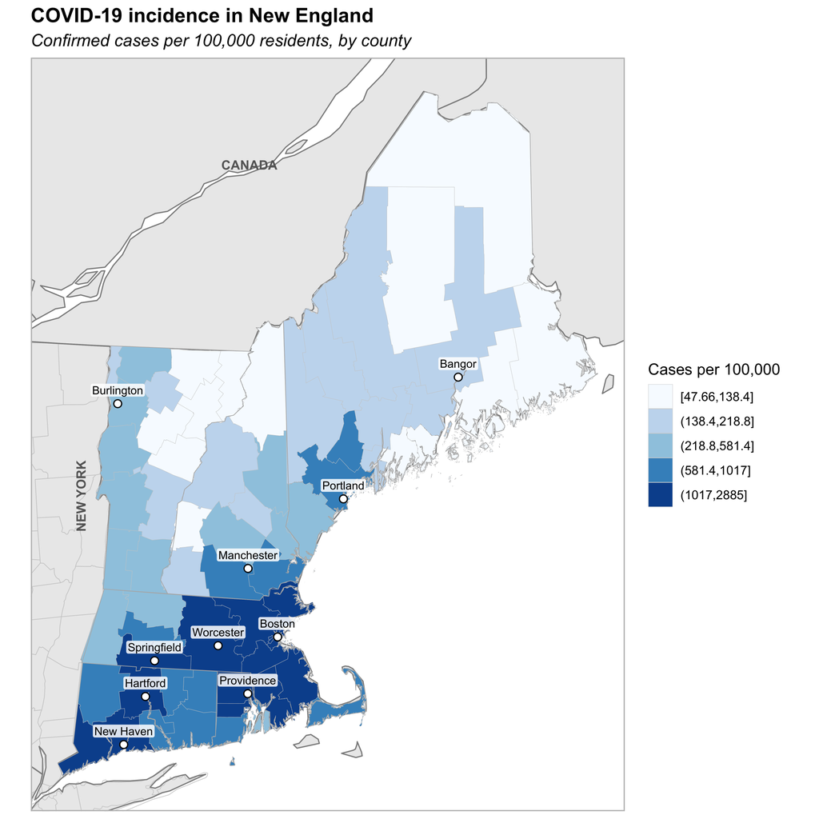

Figure 1: COVID-19 incidence by county, in quintiles, with state boundaries and major cities for reference.

### 1.1.2 Spatial Weights

A local statistic compares each county with its “neighbors,” so, as with the global statistics, every result depends on the spatial weights matrix that defines them. The choice of $W$ is a hypothesis about how far local influence reaches. To keep the focus on the local statistics themselves, this demonstration uses a single definition of neighbors, **queen contiguity**, in which two counties are neighbors if their boundaries touch at any point. That one neighbor list is converted to weights in three ways, one for each statistic:

- **Binary weights** (`style = "B"`) give every neighbor a weight of 1, as the local Getis–Ord $G_i$ expects.
- **Binary weights including the county itself** (`include.self()`) add each county to its own neighbor set, which turns $G_i$ into $G_i^*$.
- **Row-standardized weights** (`style = "W"`) rescale each county’s weights to sum to 1, so a weighted sum of the neighbors’ values is their average. These are used for local Moran’s $I_i$ and the Moran scatterplot.

```r
# One neighbor list: queen contiguity
nb_queen <- poly2nb(ne, queen = TRUE)

# Three sets of weights built from it
lw_b      <- nb2listw(nb_queen, style = "B")                 # local G_i
lw_b_star <- nb2listw(include.self(nb_queen), style = "B")   # local G_i*
lw_w      <- nb2listw(nb_queen, style = "W")                 # local Moran's I_i

# Number of neighbors and the local mean (the average rate of each county's neighbors)
ne <- ne %>%
  mutate(n_neighbors = card(nb_queen),
         local_mean  = lag.listw(lw_w, rate))
```

The local mean is the simplest local statistic. For each county it averages the incidence rates of that county’s neighbors, which is exactly the weighted sum $\sum_j w_{ij} x_j$ with row-standardized weights. In R this is the *spatial lag*, calculated with `lag.listw()`. The same quantity becomes the vertical axis of the Moran scatterplot in Section 3.

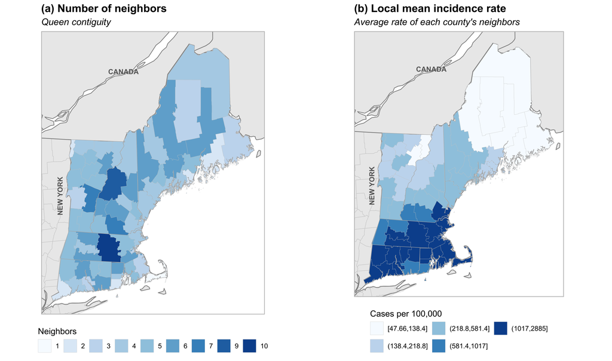

Figure 2: (a) The number of queen-contiguity neighbors of each county and (b) the local mean incidence rate, the average rate of each county’s neighbors, using the quintile classes of Figure 1.

**Interpretation:** Counties have between 1 and 10 neighbors. The 8 counties with only one or two neighbors, including Barnstable, Massachusetts and Newport, Rhode Island, all lie on the coast or the edge of the study region, where the incomplete tessellation leaves them with few others to compare against. Their local statistics will rest on very little information, which is worth remembering when they appear in a hot spot or cluster map.

The local mean map is a smoothed version of Figure 1: averaging over neighbors softens the contrast between individual counties while keeping the broad high-south, low-north pattern. Where a county differs most from its local mean, it stands out from its surroundings. The largest such difference is in Providence, Rhode Island, with a rate of 2739 against a local mean of 1215 cases per 100,000. Local Moran’s $I_i$ will turn exactly this kind of comparison, a county against the average of its neighbors, into a formal statistic.

**Considerations**

Before moving on, consider the different possible **edge effects** that might influence tests for local clusters.

- What types of edges exist in this study region? Does edge type impact the number of neighbors?
- In the context of the early COVID-19 pandemic, how could people travel across those edges?
- How might your answers to those questions change how you define which areas are neighbors of others?

# 2. Local Getis–Ord $G_i$ and $G_i^*$

The first question a health department would ask of Figure 1 is where the concentrations of high incidence and of low incidence are. The local Getis–Ord statistics can be used to answer that question. For county $i$,

$$G_i = \frac{\sum_{j \neq i} w_{ij}\, x_j}{\sum_{j \neq i} x_j}
\qquad\qquad
G_i^* = \frac{\sum_{j} w_{ij}\, x_j}{\sum_{j} x_j}$$

where $x_j$ is the incidence rate in county $j$ and $w_{ij}$ is 1 if county $j$ is a neighbor of county $i$ and 0 otherwise. $G_i$ is the share of the incidence in all the *other* counties of New England that falls in county $i$’s neighbors. $G_i^*$ is the same share with county $i$ itself included, in both the numerator and the denominator, through the `include.self()` weights built in Section 1.1.2. A county whose neighbors account for an unusually large share of the region’s incidence sits within a **hot spot**; one whose neighbors account for an unusually small share sits within a **cold spot**. Because both statistics are shares of a total, the variable must be measured on a ratio scale with a true zero, which an incidence rate is.

The spdep function `localG()` calculates both. It does not return the share itself but a $z$-score: the observed $G_i$ (or $G_i^*$) minus its expected value under spatial randomness, divided by its standard deviation. Large positive values indicate a hot spot and large negative values a cold spot.

```r
# Local G_i (neighbors only) and G_i* (neighbors plus the county itself), returned as z-scores
ne <- ne %>%
  mutate(Gi      = as.numeric(localG(rate, lw_b)),
         Gi_star = as.numeric(localG(rate, lw_b_star)))
```

The maps below class the $z$-scores at $\pm 1.96$ and $\pm 2.58$, the two-sided critical values for $p = 0.05$ and $p = 0.01$. These classes are a visual guide only. They treat each county as if it were the only test being run, which, as Section 4 shows, overstates how many hot and cold spots there are.

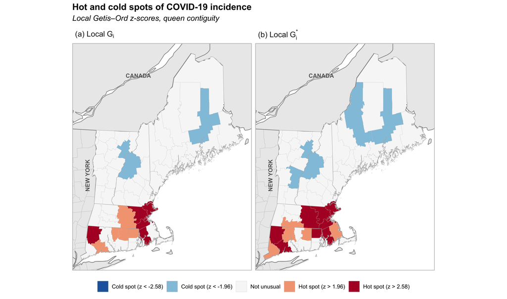

Figure 3: Hot and cold spots of COVID-19 incidence identified by (a) the local $G_i$ and (b) the local $G_i^*$ statistics.

**Interpretation:** Under $G_i^*$, 15 counties sit in hot spots and 5 in cold spots. The hot spots form one continuous band across southern New England, in 5 Connecticut, 8 Massachusetts, and 2 Rhode Island counties, strongest in Norfolk, Massachusetts ($z$ = 5.31) and the other counties around Boston. The cold spots are in the interior of northern New England, in 2 Maine, 1 New Hampshire, and 2 Vermont counties. This is the pattern the global General $G$ summarized as clustering of high values, now located on the map.

The hot spots are also much stronger than the cold spots: the largest $z$-score is 5.31, but the smallest is only -2.45. Incidence rates cannot fall below zero but can rise far above the mean, so a cluster of very high rates departs much further from the regional average than a cluster of low rates can.

The two statistics mostly agree, and where they differ the reason is whether county $i$ itself is counted. Hampden, Massachusetts; Hartford, Connecticut; Plymouth, Massachusetts; and Fairfield, Connecticut join the hot spots under $G_i^*$ because their own rates are high; including them adds their own incidence to the local total. Tolland, Connecticut drops out under $G_i^*$ for the opposite reason: its neighbors have high rates, but its own rate is lower, so including it dilutes the local total. For locating clusters, $G_i^*$ is usually the more useful of the two, because a county with a very high rate is itself part of the hot spot. $G_i$ is the better choice when the question is whether a county is *surrounded* by high values, regardless of its own value.

# 3. Local Moran’s I

The local Getis–Ord statistics locate concentrations of high or low incidence. Local Moran’s $I_i$ asks a different question: is each county’s rate *similar* to the rates of its neighbors, or *different* from them? Similar counties form clusters, as in Section 2. Counties that differ from their neighbors are **spatial outliers**: counties whose rates stand apart from their surroundings. For a health department an outlier can matter as much as a cluster: a high-rate county in an otherwise quiet region may signal a local outbreak, and a low-rate county inside the hot zone may be worth understanding as well.

For county $i$,

$$I_i = z_i \sum_{j} w_{ij}\, z_j, \qquad z_i = x_i - \bar{x}$$

where $z_i$ is the county’s deviation from the regional mean incidence rate and the weights are the row-standardized weights from Section 1.1.2, so $\sum_j w_{ij} z_j$ is the average deviation of county $i$’s neighbors. $I_i$ is positive when a county and its neighbors are on the same side of the mean (high next to high, or low next to low) and negative when they are on opposite sides (high next to low).

The spdep function `localmoran()` calculates $I_i$ for every county. It also divides each value by the variance of $x$, so the values it reports are rescaled versions of the formula above; the signs, and the ordering of the counties, are unchanged. It returns a matrix with one row per county and five columns:

1. `Ii`, the local Moran’s $I_i$ itself, rescaled by the variance; its sign shows whether the county is similar to (positive) or different from (negative) its neighbors.
2. `E.Ii`, the expected value of $I_i$ if incidence were arranged at random; it is slightly negative and, for most counties, very close to zero.
3. `Var.Ii`, the variance of $I_i$ under that same random arrangement, which differs from county to county with the number of neighbors and with how far the county’s own rate is from the mean.
4. `Z.Ii`, the $z$-score, $(I_i - E[I_i]) / \sqrt{Var[I_i]}$, which puts every county on a common scale for comparison.
5. `Pr(z != E(Ii))`, the two-sided $p$-value for that $z$-score from the normal distribution, examined in Section 4.

It also attaches a `quadr` attribute that assigns each county to one of the four quadrants of the Moran scatterplot, used in Section 3.1.

```r
# Local Moran's I with row-standardized queen-contiguity weights
lisa <- localmoran(ne$rate, lw_w)

# Keep the statistic and the scatterplot quadrant for each county
ne <- ne %>%
  mutate(Ii   = lisa[, "Ii"],
         quad = attr(lisa, "quadr")$mean)

# Show the five columns for the first six counties
head(lisa) %>% as.data.frame() %>%
  rename(Ii = Ii, E_Ii = E.Ii, Var_Ii = Var.Ii, Z_Ii = Z.Ii, p_value = `Pr(z != E(Ii))`) %>%
  knitr::kable(digits = c(3, 3, 3, 3, 4), caption = "Local Moran's I for the first six counties")
```

Local Moran’s I for the first six counties

| Ii | E_Ii | Var_Ii | Z_Ii | p_value |
| --- | --- | --- | --- | --- |
| 0.527 | -0.008 | 0.076 | 1.940 | 0.0524 |
| 0.661 | -0.012 | 0.249 | 1.350 | 0.1770 |
| 0.564 | -0.008 | 0.077 | 2.060 | 0.0394 |
| 0.677 | -0.011 | 0.175 | 1.643 | 0.1004 |
| 0.380 | -0.007 | 0.113 | 1.153 | 0.2489 |
| 0.281 | -0.008 | 0.084 | 1.002 | 0.3164 |

Local Moran’s $I_i$ is also a decomposition of the global statistic. With row-standardized weights, the average of the 65 local values is exactly the global Moran’s $I$:

```r
# The mean of the local values equals the global Moran's I
c(mean_local_I = mean(ne$Ii),
  global_I     = moran(ne$rate, lw_w, n = nrow(ne), S0 = Szero(lw_w))$I) %>%
  knitr::kable(digits = 3, caption = "Mean of the local Moran's I equals the global Moran's I")
```

Mean of the local Moran’s I equals the global Moran’s I

|  | x |
| --- | --- |
| mean_local_I | 0.659 |
| global_I | 0.659 |

Each county’s $I_i$ is its contribution to the global value, so mapping $I_i$ shows *where* the global autocorrelation found in the previous demonstration comes from.

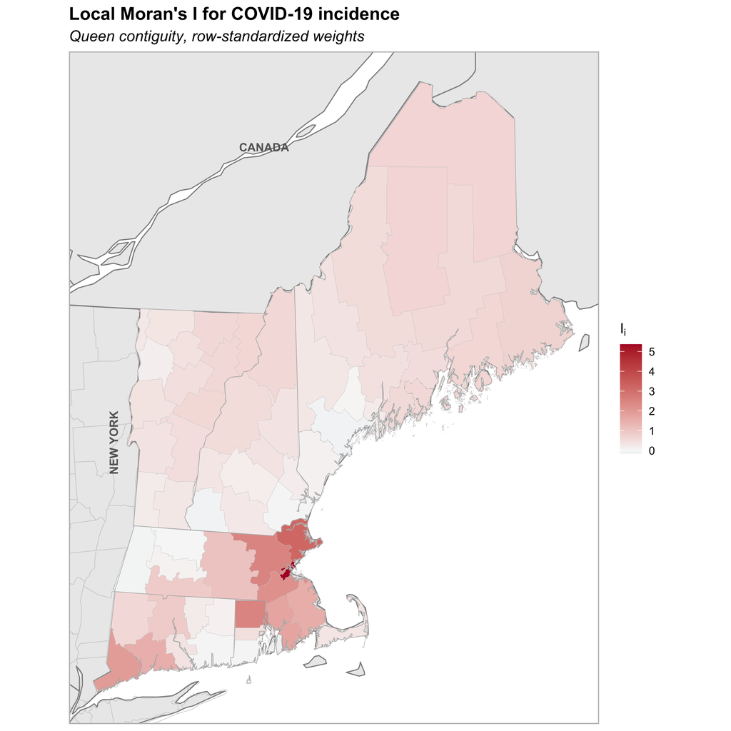

Figure 4: Local Moran’s $I_i$ for COVID-19 incidence by county.

**Interpretation:** The largest values are all in southern New England, led by Suffolk, Massachusetts ($I_i$ = 5.36). The five largest, Suffolk, Massachusetts; Essex, Massachusetts; Middlesex, Massachusetts; Providence, Rhode Island; and Norfolk, Massachusetts, together account for 37% of the sum of all 65 local values, so a handful of high-rate counties around Boston and Providence produce much of the global Moran’s $I$. Suffolk, Massachusetts also illustrates a limitation: it has only 3 neighbors, and its value is large partly because its own rate is the highest in the region. A large $I_i$ can come from an extreme county as much as from a broad cluster. Negative values, which would mark spatial outliers, are rare and small: 7 counties have $I_i < 0$, and the most negative, Newport, Rhode Island, is only -0.16. Across most of the north the values are small and positive, low-rate counties next to low-rate counties, which add only a little to the global statistic.

## 3.1 Moran Scatterplot and Cluster Map

The sign of $I_i$ says whether a county is similar to its neighbors, but not whether the similarity is high–high or low–low. The **Moran scatterplot** separates the two. It plots each county’s standardized incidence rate against the average standardized rate of its neighbors, the local mean of Figure 2(b) on a standardized scale. Lines at zero (the regional mean) divide it into four quadrants:

- **High–High** (upper right): a high-rate county with high-rate neighbors.
- **Low–Low** (lower left): a low-rate county with low-rate neighbors.
- **High–Low** (lower right): a high-rate county with low-rate neighbors, a spatial outlier.
- **Low–High** (upper left): a low-rate county with high-rate neighbors, a spatial outlier.

Counties in the High–High and Low–Low quadrants have positive $I_i$; those in the other two have negative $I_i$. The slope of a line fitted through the points is the global Moran’s $I$. Mapping the quadrant of each county gives a **cluster map**, often called a LISA map because local Moran’s $I_i$ is a Local Indicator of Spatial Association (Anselin, 1995).

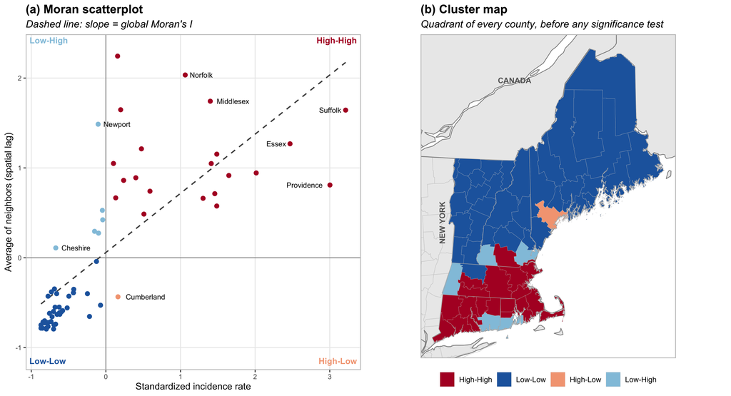

Figure 5: (a) Moran scatterplot of COVID-19 incidence and (b) the quadrant of each county mapped as a cluster map. No significance test has been applied.

**Interpretation:** Most counties fall in the two quadrants that produce positive spatial autocorrelation: 37 are Low–Low, covering nearly all of northern New England, and 21 are High–High, covering most of the south. Only 7 counties fall in the outlier quadrants, and they lie mostly along the boundary between the two zones, where a county on one side of the regional mean borders counties on the other. The single High–Low county is Cumberland, Maine, a county with a higher rate than its neighbors; one plausible reason is that it contains Portland, Maine’s largest city, but the map alone cannot show why.

Figure 5(b) colors every county by its quadrant, and that is not the same as identifying clusters. A county sitting just above the mean next to neighbors just above the mean is High–High, even though nothing about it is unusual. Deciding which of these counties are unusual enough to report is the job of the next section.

# 4. Inference and Multiple Testing

Sections 2 and 3 classed every county as a hot spot, cold spot, cluster, or outlier without asking whether its value is actually unusual. A county can be High–High simply because it and its neighbors sit a little above the regional mean. Deciding which counties to report raises two separate problems:

1. **Getting a trustworthy $p$-value for each county.** The $p$-values from `localmoran()` assume the statistic follows a normal distribution, which is doubtful when a county has only a few neighbors and when the rates are as skewed as these.
2. **Testing 65 counties at once.** Even if every $p$-value were correct, testing each county at $\alpha = 0.05$ would be expected to flag about $65 \times 0.05 \approx 3$ counties by chance alone, and neighboring counties share many of the same neighbors, so their tests are not independent.

## 4.1 Analytic- versus Permutation-Based Approaches to Inference

**Conditional permutation** avoids the normality assumption. For each county, its own rate is held fixed while the rates of all the other counties are randomly shuffled among its neighbors; $I_i$ is recalculated for each shuffle, and the observed $I_i$ is compared with the values from the shuffles.

The spdep function `localmoran_perm()` does this for every county. It takes the same arguments as `localmoran()`, plus `nsim`, the number of shuffles, and `iseed`, a random seed that makes the results reproducible. The pseudo $p$-value is in the column `Pr(z != E(Ii)) Sim`.

```r
# Conditional permutation test of local Moran's I: 9,999 shuffles, seed set for reproducibility
lisa_perm <- localmoran_perm(ne$rate, lw_w, nsim = 9999, iseed = 172)

# Keep the analytic (normal) and permutation p-values for each county
ne <- ne %>%
  mutate(p_analytic = lisa[, 5],
         p_perm     = lisa_perm[, "Pr(z != E(Ii)) Sim"])
```

Every county now has two $p$-values for the same statistic: one from the normal distribution and one from permutation. If the normal distribution were a good description of how $I_i$ behaves under spatial randomness, the two would agree, and it would not matter which we used. Figure 6 checks whether the two sets of $p$-values align. Each point is one county. Its position along the horizontal axis is its analytic $p$-value, and its position along the vertical axis is its permutation $p$-value. Both axes are on a log scale, so the very small $p$-values of the strongest clusters are spread out rather than piled up against zero; values toward the lower left are more significant. The dashed diagonal line marks where the two $p$-values would be equal. Points below the line are more significant under permutation than under the normal distribution, and points above it are less significant. The gray lines at 0.05 divide the plot into four regions: counties in the gray box at the lower left are significant under both methods, counties in the upper right under neither, and counties in the other two regions are significant under one method but not the other. Those last counties, drawn with a heavy outline, are the ones where the choice of method changes the answer. Point colors show each county’s Moran scatterplot quadrant from Figure 5, so we can see whether the disagreements fall on high-rate or low-rate clusters.

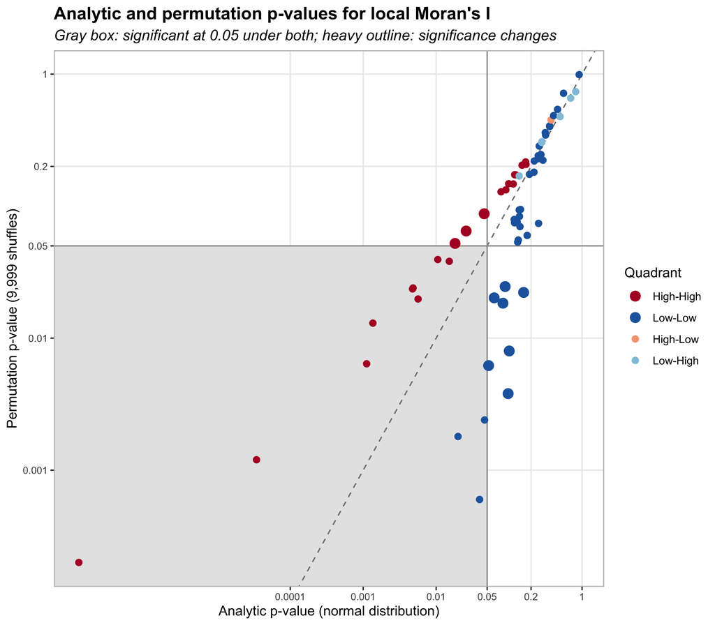

Figure 6: Analytic and permutation $p$-values for local Moran’s $I_i$, on log scales, colored by Moran scatterplot quadrant. Counties with a heavy outline are significant at 0.05 under one method but not the other.

**Interpretation:** The two sets of $p$-values follow the same general pattern (correlation 0.76 on the log scale), but they disagree about which counties are significant at 0.05. The analytic $p$-values flag 15 counties, 12 High–High and 3 Low–Low. The permutation $p$-values flag 19, 9 High–High and 10 Low–Low. The 7 counties that become significant under permutation are all Low-Low counties, mostly in northern New England, while the 3 that lose significance, Tolland, Connecticut; Providence, Rhode Island; and New Haven, Connecticut, are all High-High.

The reason is the skew in the incidence rates. Because a few counties have very high rates, the values of $I_i$ produced by random shuffling are lopsided rather than normal: an occasional shuffle that places one of those very high rates next to a county produces an extreme value. The normal distribution does not capture that shape, so it overstates how unusual the high-rate clusters are and understates how unusual the low-rate ones are. For the rest of this section, the permutation $p$-values are used.

## 4.2 How Many Counties Are Significant?

Permutation gives each county a better $p$-value, but it does nothing about the multiple testing problem. There are three common ways to address this problem.

- **Bonferroni** tests each county at $\alpha' = \alpha / n$, here $0.05 / 65 \approx$ 0.00077.
- **Šidák** tests each county at $\alpha' = 1 - (1 - \alpha)^{1/n}$, here 0.00079, almost the same.
- **False discovery rate (FDR)** adjusts the $p$-values so that, among the counties called significant, the expected proportion of false positives is at most $\alpha$. It is less strict than Bonferroni and Šidák. In R it is `p.adjust(p, method = "fdr")`.

The table counts the counties called significant at $\alpha = 0.05$ under each approach. A third row repeats the permutation test with only 999 shuffles.

```r
# The same permutation test with 999 shuffles, for comparison
p_999 <- localmoran_perm(ne$rate, lw_w, nsim = 999, iseed = 172)[, "Pr(z != E(Ii)) Sim"]

# Count the counties significant at 0.05 with no correction and under each correction
n <- nrow(ne)
count_sig <- function(p) {
  c(`No correction` = sum(p < 0.05),
    FDR             = sum(p.adjust(p, method = "fdr") < 0.05),
    `Šidák`         = sum(p < 1 - 0.95^(1 / n)),
    Bonferroni      = sum(p < 0.05 / n))
}

rbind(`Analytic (normal)`        = count_sig(ne$p_analytic),
      `Permutation, 9,999 shuffles` = count_sig(ne$p_perm),
      `Permutation, 999 shuffles`   = count_sig(p_999)) %>%
  kable(align = "rrrr") %>%
  kable_styling(full_width = T)
```

|  | No correction | FDR | Šidák | Bonferroni |
| --- | --- | --- | --- | --- |
| Analytic (normal) | 15 | 4 | 2 | 2 |
| Permutation, 9,999 shuffles | 19 | 6 | 2 | 2 |
| Permutation, 999 shuffles | 19 | 6 | 0 | 0 |

**Interpretation:** Without any correction, 19 counties look significant. Controlling the false discovery rate cuts that to 6, and Bonferroni or Šidák to 2. Most of the clusters in the uncorrected results do not hold up once the number of tests is taken into account.

The 999-shuffle row shows a practical limit. With $m$ shuffles the smallest possible two-sided pseudo $p$-value in spdep is $2/(m + 1)$, which is 0.002 for 999 shuffles, larger than the Bonferroni threshold of 0.00077. No county can pass Bonferroni with 999 shuffles, however strong its clustering, which is why this demonstration uses 9,999.

## 4.3 Significance-Filtered Cluster Maps

The final step is to map only the counties that survive each test. Counties that do not are drawn as “Not significant.”

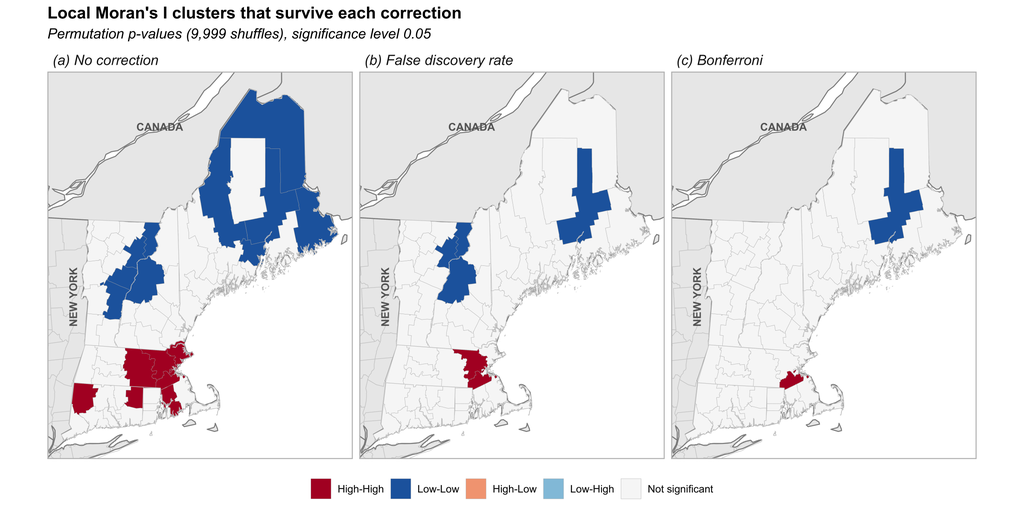

Figure 7: Local Moran’s $I_i$ cluster map with (a) no correction, (b) a false discovery rate correction, and (c) a Bonferroni correction for multiple testing.

**Interpretation:** Without a correction, the map shows a broad High–High band across southern New England and a broad Low–Low area in the north, much like Figure 5(b). With the false discovery rate correction only 6 counties remain: Penobscot, Maine; Essex, Vermont; Grafton, New Hampshire; Caledonia, Vermont; Middlesex, Massachusetts; and Norfolk, Massachusetts. With Bonferroni only 2 remain: Penobscot, Maine and Norfolk, Massachusetts. The broad regions of Figure 5(b) shrink to a few core counties, and no spatial outliers survive any correction. The same corrections applied to the $G_i^*$ permutation test give a similar result: 5 counties remain after the false discovery rate correction and 1 after Bonferroni.

Which map a health department should use depends on the cost of each kind of mistake. The uncorrected map will include counties that are not truly unusual, which wastes resources on false alarms. The Bonferroni map will miss real clusters, which in a pandemic could mean a hot spot that goes unnoticed. The false discovery rate is a common compromise because it accepts a known share of false alarms in exchange for not missing as many real clusters.

# 5. Comparison and Interpretation

Getis and Ord (1992) recommend using their statistic and local Moran’s $I_i$ together, because the two measure different things. $G_i^*$ asks whether a county sits within a concentration of high or low values. $I_i$ asks whether a county is similar to or different from its neighbors, whatever the level of its values. A county can be part of a Low–Low cluster without being in an unusually strong cold spot, and a spatial outlier has no counterpart in $G_i^*$ at all. The table below cross-classifies every county by its $G_i^*$ class from Figure 3(b) and its Moran scatterplot quadrant from Figure 5, before any significance test.

```r
# Cross-classify each county by its G_i* class and its local Moran quadrant (no significance test)
ne <- ne %>%
  mutate(g_class = case_when(Gi_star >  1.96 ~ "Hot spot",
                             Gi_star < -1.96 ~ "Cold spot",
                             TRUE            ~ "Not unusual"),
         g_class = factor(g_class, levels = c("Hot spot", "Not unusual", "Cold spot")))

table(`G_i*` = ne$g_class, `Local Moran quadrant` = factor(ne$quad, levels = quad_levels)) %>%
  as.data.frame.matrix() %>%
  kable(align = "rrrr") %>%
  kable_styling(full_width = T)
```

|  | High-High | Low-Low | High-Low | Low-High |
| --- | --- | --- | --- | --- |
| Hot spot | 15 | 0 | 0 | 0 |
| Not unusual | 6 | 32 | 1 | 6 |
| Cold spot | 0 | 5 | 0 | 0 |

**Interpretation:** The two statistics never contradict each other. Every hot spot is a High–High county and every cold spot is a Low–Low county. But they draw very different boundaries. 6 High–High counties and 32 Low–Low counties are not unusual according to $G_i^*$: they are on the same side of the regional mean as their neighbors, but their concentration of high or low values is not strong enough to stand out. The 7 spatial outliers identified by $I_i$ are all “not unusual” to $G_i^*$, which by design cannot detect a county that differs from its surroundings.

The more important comparison is after the inference of Section 4. The map below combines the two tests, using permutation $p$-values and the false discovery rate correction for both.

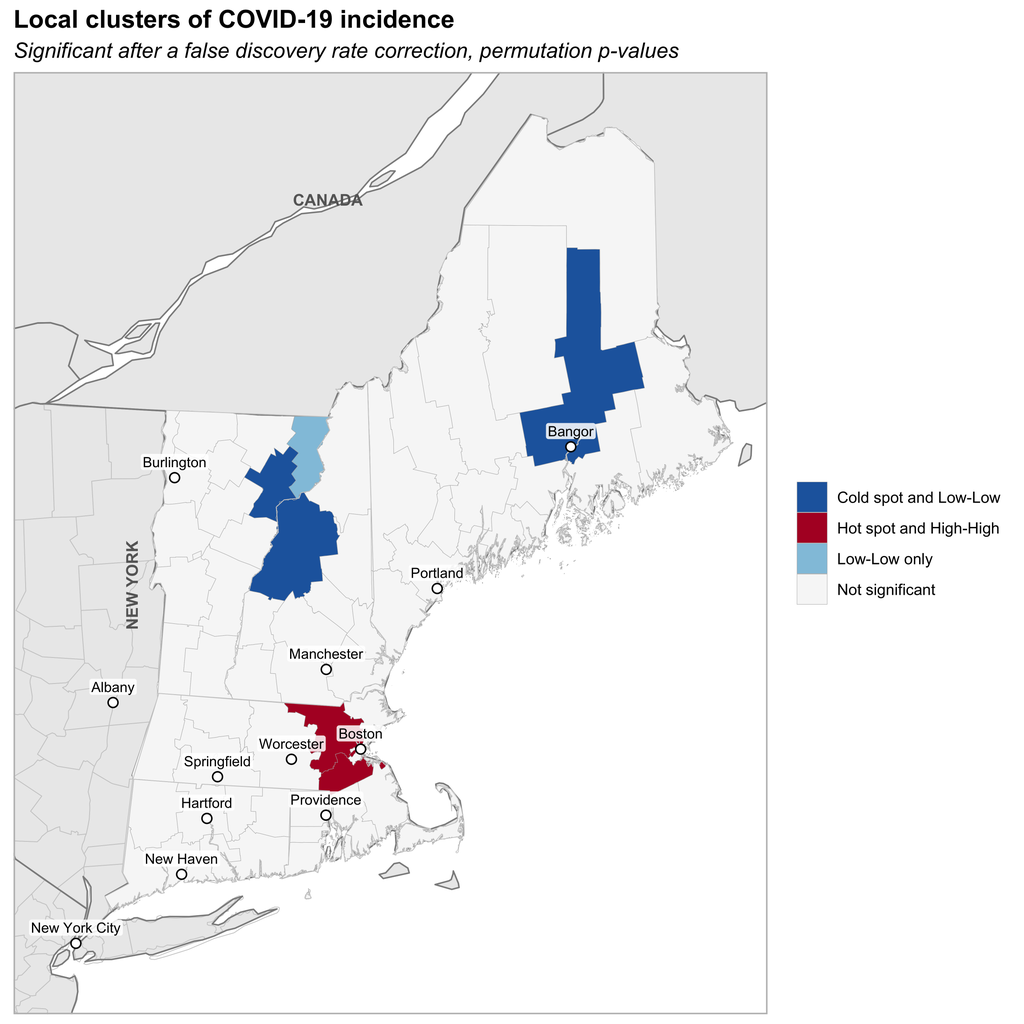

Figure 8: Counties identified as local clusters of COVID-19 incidence by $G_i^*$, local Moran’s $I_i$, or both, after a false discovery rate correction for multiple testing.

**Interpretation:** After inference, the two statistics largely agree. 5 counties are significant under both: Middlesex, Massachusetts and Norfolk, Massachusetts form the core of the high-incidence cluster, and Penobscot, Maine; Grafton, New Hampshire; and Caledonia, Vermont form the core of the low-incidence cluster. Essex, Vermont is significant only under $I_i$. No county is significant only under $G_i^*$.

This is a very different picture from the one we started with. Figure 3 showed 15 hot-spot counties across southern New England and only 5 cold-spot counties in the north, and Figure 5(b) colored nearly every county as part of a cluster. Once the skew in the rates is handled by permutation and the 65 tests are accounted for, the evidence is about as strong for the low-incidence core in northern New England as for the high-incidence core around Boston, and the broad regions shrink to a handful of counties. None of this changes the conclusion of the global statistics, that incidence is spatially clustered, but it changes what we can say about *where*.

For the health department of the introduction, a defensible report would say three things. First, the counties around Boston, with Middlesex, Massachusetts and Norfolk, Massachusetts at their center, form a statistically robust cluster of high incidence and are the clearest place to direct testing and resources. Second, the interior of northern New England forms a cluster of low incidence that is just as robust, which is itself useful information for planning. Third, every result depends on choices made along the way: queen contiguity as the definition of neighbors, a coastline and a missing pair of island counties that leave some counties with very few neighbors, and the correction chosen for multiple testing. A different and equally defensible set of choices could move the boundaries of these clusters, so the maps are best read as evidence about where to look more closely, not as a final answer.

**Considerations**

Consider again the possible importance of **edge effects** in this study.

Figure 8 marks Albany, NY and New York City, NY. It was well established, even at the time, that New York City was a center of the early pandemic, with COVID-19 cases overwhelming the city’s healthcare system. The commuting area for New York City also extends well into Connecticut and up the Hudson toward Albany. How might the design of this study be changed to account for this reality?

### Declaration of Generative AI and AI-Assisted Technologies

The author used Anthropic’s Claude (Opus 5.5) when developing this demonstration. A connection to RStudio through the ClaudeR package was used to draft and debug the R code. The author subsequently reviewed and edited all of that output and takes full responsibility for the content.